# slide_deck_template slides

#### Table of content:

1. Introduction 2. Univariate Study 3. Bivariate Study 4. Multivariate Study 5. Missing Values 6. Summary

### Q. What are important features in the dataset that should be taken into consideration to perform analysis and study its distribution?

**Answer** Studying the dataset to predict the house prices, not all features were as important as few of them. Therefore making choices to figure out the latent features which, I figured out that following variables can play a important role:

- OverallQual (The overall quality of the house which can be concluded taking all other features into account.)
- YearBuilt (The year in which the house is built, whether new or old.)
- TotalBsmtSF (Total basement area in square feet is an important feature related to the proce of any house.)
- GrLivArea (Ground living area is square feet of area in which house is built.)

I ended up with two 'building' variables ('OverallQual' and 'YearBuilt') and two 'space' variables ('TotalBsmtSF' and 'GrLivArea').

### Q. How is the dependent feature,ie Sale Price distribured in the set?

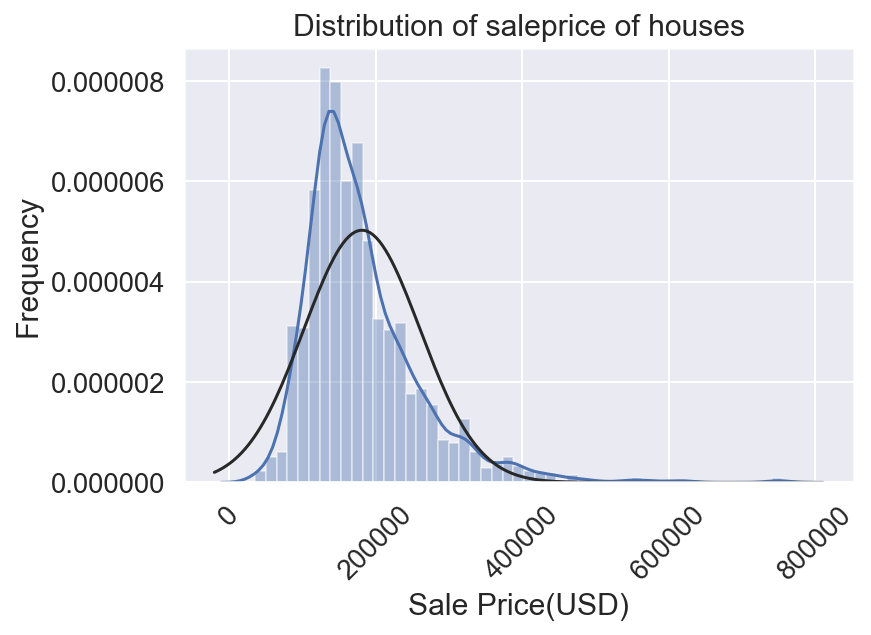

### Q. Is there any relation between total ground living area and the sale price of the house?

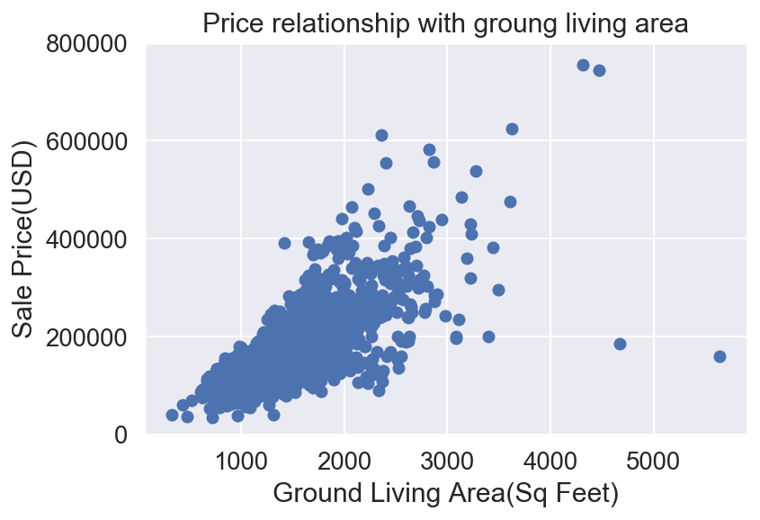

**Answer:** It seems that sale price and ground living area shows linear relationship.

### Q. How is sale price related with total basement area?

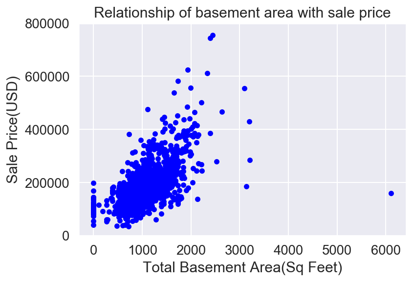

### Q. Does overall quality of a house has an impact on its sale price?

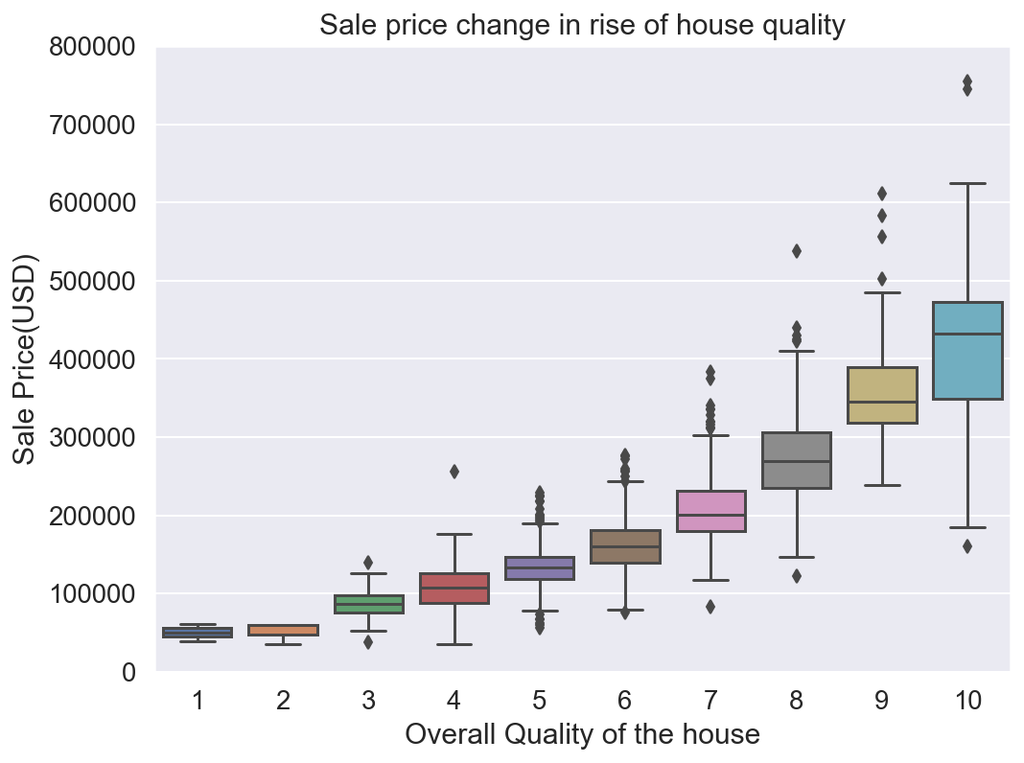

**Answer:** It can be understood from above boxplot that as there is increase in the quality of the house, the sale price also rises.

### Q. Does the year in which house was built has any impact on its sale price?

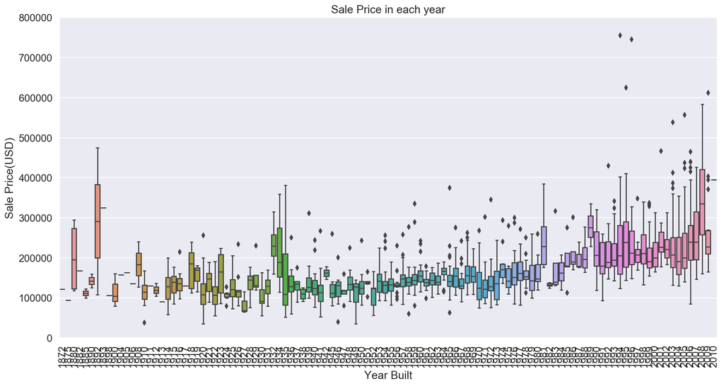

**Answer:** Clearly, it can be noticed that sale price is more prone to recently built houses than older ones.

### Q. Can we figure out multicollinearity in the data?

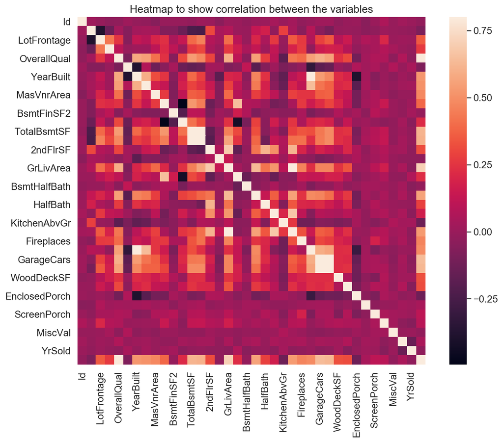

**Answer:** The above figure shows a heatmap with its colorbar stating the correlation between the variables. It can be seen whether a variable is highly, moderatly or not realted with the sale price and amongst each other.

### Q. Can you show realtionship between various variables?

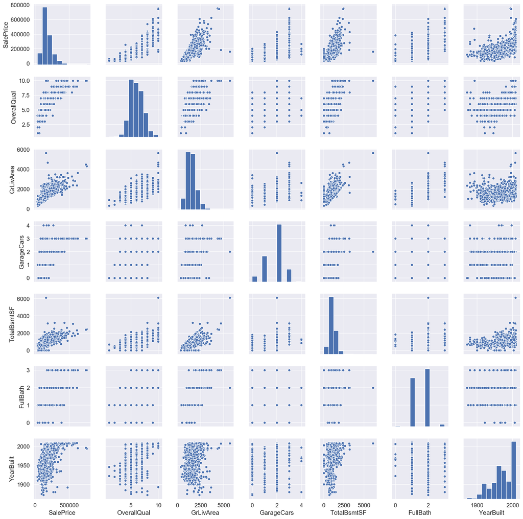

**Answer:** This mega scatter plot gives us a reasonable idea about variables relationships.

- One of the figures we may find interesting is the one between 'TotalBsmtSF' and 'GrLiveArea'. In this figure we can see the dots drawing a linear line, which almost acts like a border. It totally makes sense that the majority of the dots stay below that line. Basement areas can be equal to the above ground living area, but it is not expected a basement area bigger than the above ground living area (unless you're trying to buy a bunker).
- The plot concerning 'SalePrice' and 'YearBuilt' can also make us think. In the bottom of the 'dots cloud', we see what almost appears to be a shy exponential function. We can also see this same tendency in the upper limit of the 'dots cloud'. Also, notice how the set of dots regarding the last years tend to stay above this limit (I just wanted to say that prices are increasing faster now).

### Q. How to convert a feature into normal distribution? What is the use of this method?

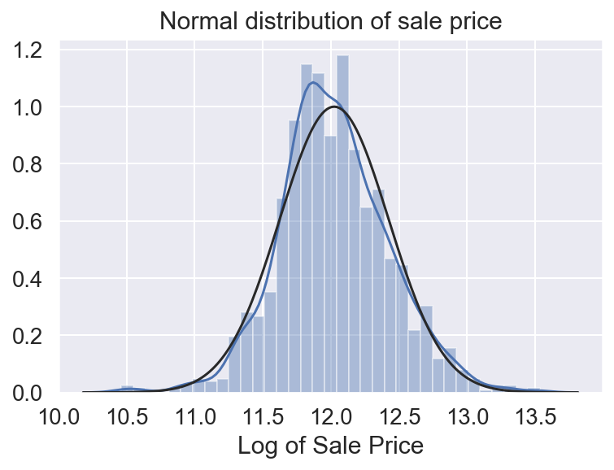

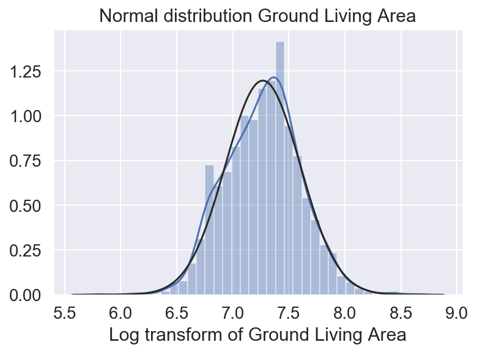

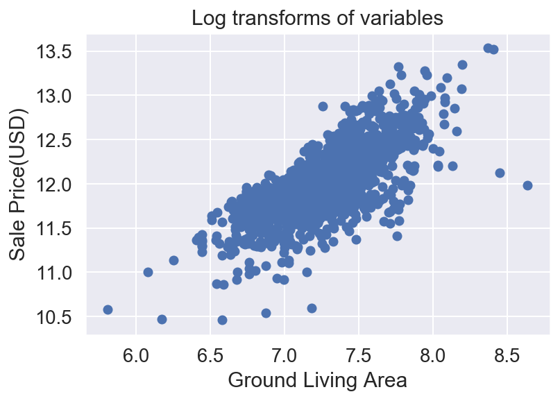

**Answer:**

To convert a feature into normal distribution, we use different transformation method. One of those method is to convert the feature into natural log transform.

Older versions of this scatter plot (previous to log transformations), had a conic shape. As you can see, the current scatter plot doesn't have a conic shape anymore. That's the power of normality!

We can conclude that:

'GrLivArea' and 'TotalBsmtSF' seem to be linearly related with 'SalePrice'. Both relationships are positive, which means that as one variable increases, the other also increases. In the case of 'TotalBsmtSF', we can see that the slope of the linear relationship is particularly high.

'OverallQual' and 'YearBuilt' also seem to be related with 'SalePrice'. The relationship seems to be stronger in the case of 'OverallQual', where the box plot shows how sales prices increase with the overall quality.

We used log transformation method to convert a variable into normal distribution and also by implementing this method we reduced the variace in data which can be seen in the last scatter plot between Ground Living Area and Sale Price.